# Effects of Impeachment on Donald Trump’s Donors

Will Godwin - 1/17/2020

**NOTE**: This analysis will be updated with FEC data through 12/31/2019 once those data become available in the coming weeks.

# Intro

With escalating U.S.-Iran tensions reaching [near-war outcomes](https://apnews.com/b687c7be0a03c2c6c53397c2f9406f24) and long-awaited democratic caucuses set to begin, the impeachment inquiry can momentarily slip from political view. But, indeed the U.S. 44th president, Donald John Trump, was impeached by the House of Representatives last December and the trial in the Senate began yesterday at the time of print. As the impeachment trial progresses, a pressing question is how Americans are processing and responding to the proceeding. One quantifiable response is political donations, particularly to Trump’s re-election campaigns. Here, I investigated time trends in donations to Trump’s re-election campaigns across the U.S., stratifying by political orientation based on 2016 presidential election results. Additionally, I investigated these trends within swing states that contain many moderate voters and will likely decide the 2020 general election.

```r
#read donation data
#main presidential pac-https://www.fec.gov/data/
df <- read_csv(don_filepath)
df2 <- read_csv(don_filepath2)
df <- bind_rows(df, df2)
df <- df %>% as_tibble(.name_repair = "unique")

#restrict to relevant columns
df <- df %>%
  mutate(date=as.Date(contribution_receipt_date)) %>%
  select(contributor_zip, contribution_receipt_amount, date, contributor_name)
```

# Data and Prep

Donations data was downloaded from a [database](https://www.fec.gov/data/) run by the Federal Election Commission, which houses all campaign finance data for public use and consumption. Data were downloaded from 01/01/2019-09/31/2019, the most recent data available in the FEC database. Contributions to “Donald J. Trump for President, INC.”, “Trump Make America Great Again Committee”, and “Trump Victory” PACs were exported and bound together.

These data are at the individual-level and also contain each donors zip code. In order to link donors to the voting history of their community, I joined zip codes with voter precincts and their results from 2016 presidential election. However, this linkage required careful management since often the boundaries of one zip code may overlap with multiple voting precincts or vice versa. In the instance that a zip code contained multiple voting precincts which all voted for the same candidate in 2016, that zip code was included in the final dataset. In the instance that a zip code contained voting precincts where the most popular candidate differed, those zip codes were dropped from the final dataset.

There were 5,595 zip codes (of 33,664) containing 2+ voter precincts; 30% (1655/5595) of which contained precincts with conflicting candidate preferences and were excluded from the analysis. Other data quirks included negative contribution amounts in 1.4% of the data. These data were excluded in a sensitivity analysis and qualitatively similar results were observed. For time-series figures, data were tabulated to donation totals by month, stratified by 2016 candidate preference for the collective U.S. and individual swing states.

```r
# Steps of data prep:
# 1. Read in voting history by congressional district
# 2. Read in file that links zip code to congressional district (roughly-there are some errors in this, one example is districts AL-06 and AL-07 belong to the same zip code, 35005, but have extremely different political leanings. And conversely, multiple congressional districts can belong to one zip code so it gets a bit messy)
# 3.
#read in party leaning data by congressional district
df_vot <- read_csv(vot_filepath) %>%
  mutate_at(vars(contains("%")), as.double)

#read zip code to congressional district data
df_zip <- read_csv(zip_filepath) %>% #https://www.census.gov/geographies/reference-files/2010/geo/relationship-files.html
  mutate(State=as.integer(State)) %>%
  left_join(state.fips %>% select(fips, abb) %>% distinct(fips, .keep_all = T), #must drop non-unique rows
            by=c("State"="fips")) %>% #merge on state abbrev
  mutate(district=formatC(`Congressional District`, width = 2,
                          format = "d", flag = "0"), #add leading zero to district variable
         state_dist=paste0(abb, "-", district), #concatenate state abbrev and district
         ZCTA=as.character(ZCTA)) %>%
  select(ZCTA, state_dist)

#good article describing issues w linking zip and cong district-https://www.azavea.com/blog/2017/07/26/accuracy-zip-district-matching/
#merge together zip codes with the congressional district voting record
df_vot_zip <- right_join(df_vot, df_zip, by=c("Dist"="state_dist"))

#address the duplicate zip codes before joining with contribution data
#there are multiple districts in one zip code. These zip codes tend to
#be blue so when I joined the contributions data and the voter history on zip
#code, these rows were duplicated, falsely increasing blue districts contributions.
dup_zips <- df_vot_zip %>% filter(duplicated(ZCTA)) %>% pull(unique(ZCTA))
t5 <- df_vot_zip %>% filter(ZCTA %in% dup_zips) %>% arrange(ZCTA) %>%
  mutate(trump_value=`Trump %` - `Clinton %`,
         Party=case_when(trump_value>0 ~ 1, trump_value<0 ~ 0)) %>%
  group_by(ZCTA) %>%
  summarise(p=mean(Party))
#table(t5$p)
confl_zips <- t5 %>% filter(p>0 & p<1) %>% pull(unique(ZCTA))


df_vot_zip <- df_vot_zip %>%
  #drop zip codes that have multiple districts supporting opposing parties
  filter(ZCTA %in% setdiff(ZCTA, confl_zips)) %>%

  #keep the first row for each unique zip code since remaining zip codes
  #w/ 2+ districts all support same party
  distinct(ZCTA, .keep_all = T)

#merge voting records with donations by zip code
df1 <- left_join(df, df_vot_zip, by=c("contributor_zip"="ZCTA"))

#read in population to generate per capita cost - https://data.world/lukewhyte/us-population-by-zip-code-2010-2016
df_pop <- read_csv(pop_filepath) %>%
  select(zip_code, pop=`y-2016`)

#merge on population and format month variable
df1 <- left_join(df1, df_pop, by=c("contributor_zip"="zip_code")) %>%
  mutate(month=as.Date(paste0(substr(date, 1, 7), "-01")),
         week =as.Date(paste0(substr(date, 1,4), "-", week(date), "-", 1),
                                     format="%Y-%U-%u"),
         trump_value=`Trump %` - `Clinton %`)
```

# Results

During this time there were 721553 total contributions, totaling $47.98 million. As shown below, the major upswing began in July and continued through September. Average size of donation, a proxy for strength of support, $66.5 over the course of 2019. Weekly donation totals were fairly steady from January-June, with zip codes that Trump won with the popular vote consistently outspending zip codes that Clinton won. Donation campaigns in June and July kicked off a significant surge in money to Trump’s PACs. Nancy Pelosi annouced a formal impeachment inquiry on September 24, which coincides with a massive surge in donations throughout the country.

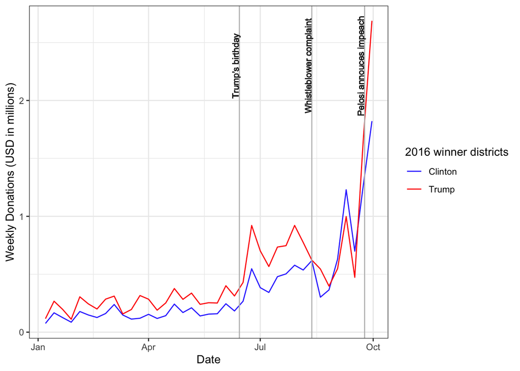

```r
#force R to not use exponential notations
options("scipen"=100, "digits"=4)

#generate voting indicators
party_colors <- c("#333BFF", "red")
df1 %>%
  mutate(Party=case_when(trump_value>0 ~ "Trump", trump_value<0 ~ "Clinton")) %>%
  filter(!is.na(Party)) %>%
  group_by(week, Party) %>%
  summarise(total_dollars=sum(contribution_receipt_amount, na.rm = T)/1000000,
            total_cons=n(),
            total_uni_cons=length(unique(contributor_name))) %>%
  ggplot() +
  geom_line(aes(week, total_dollars, color=Party)) +
  scale_color_manual(values = party_colors, guide=guide_legend("2016 winner districts")) +
  #geom_text(aes(month, total_dollars, label=total_uni_cons)) +
  geom_vline(xintercept = as.Date("2019-06-14"), col="grey") +
  geom_text(aes(x=as.Date("2019-06-11"), label="Trump's birthday", y=2.3),
            colour="grey16", angle=90, size=3) +
  geom_vline(xintercept = as.Date("2019-08-12"), col="grey") +
  geom_text(aes(x=as.Date("2019-08-09"), label="Whistleblower complaint", y=2.3),
            colour="grey16", angle=90, size=3) +
  geom_vline(xintercept = as.Date("2019-09-24"), col="grey") +
  geom_text(aes(x=as.Date("2019-09-21"), label="Pelosi annouces impeach", y=2.3),
            colour="grey16", angle=90, size=3) +
  labs(x="Date", y="Weekly Donations (USD in millions)") +
  theme_bw()
```

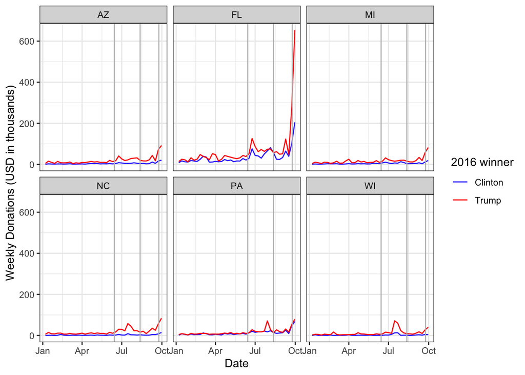

```r
#facet wrap the plot on specific states
states_ab <- c("WI", "MI", "PA", "AZ", "NC", "FL")
plotStatesFacet <- function(states, df_plot=df1, df_zip_fun=df_zip){
  #find zip codes for that state
  all_zips <- unlist(map(states, zipsBystate, df=df_zip_fun))

  #build plot
  df_plot %>%
    mutate(Party=case_when(trump_value>0 ~ "Trump", trump_value<0 ~ "Clinton"),
           state=substr(Dist, 0, 2)) %>%
    filter(!is.na(Party) & contributor_zip %in% all_zips) %>%
    group_by(week, Party, state) %>%
    summarise(total_dollars=sum(contribution_receipt_amount, na.rm = T)/1000) %>%
    ggplot() +
    geom_line(aes(week, total_dollars, color=Party)) +
    scale_color_manual(values = party_colors, guide=guide_legend("2016 winner")) +
    facet_wrap(~state) +
    geom_vline(xintercept = as.Date("2019-06-14"), col="grey") +
    geom_vline(xintercept = as.Date("2019-08-12"), col="grey") +
    geom_vline(xintercept = as.Date("2019-09-24"), col="grey") +
    labs(x="Date", y="Weekly Donations (USD in thousands)") +
    theme_bw()
}

#plot
plotStatesFacet(states = states_ab)
```

The gray vertical lines are defined as follows: 1st-Trump’s birthday, 2nd-Whistleblower complaint becomes public, 3rd-Pelosi announce formal impeachment inquiry.